# Residuals

```r
library(mosaic)
library(tidyverse)
library(pander)
library(ggplot2)
library(DT)
rex <- data.frame(
  daysaway = c(7,6,5,4,3,2,1),
  high = c(33,34,34,19,27,25,30),
  humid = c(85,89,78,78,78,73,65),
  lastyearhigh = c(39,37,34,30,18,12,7),
  clouds1to5 = c(4,5,5,4,4,2,3)
)
```

Here we have our regression of temperature from last week. Each dot (or $Y_i$) is a temperature from previous days, and the line shows our expected temperature based on the trends in temperature.

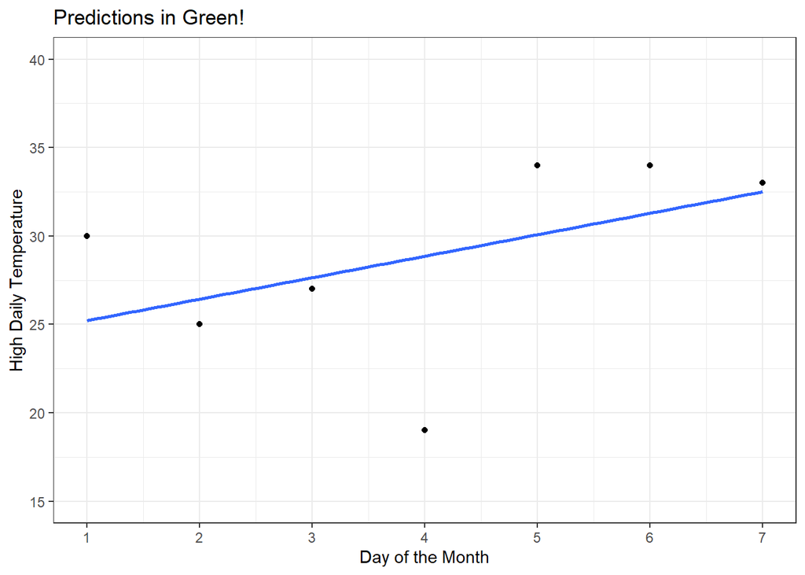

```r
rex.lm <- lm(high~daysaway,data=rex)
b <- rex.lm$coefficients
ggplot(rex,aes(x=daysaway,y=high)) + geom_point() + geom_point(x=9,y=34.92857,size=3,color='green') +
  geom_smooth(method='lm',se=FALSE,formula=y~x) + theme_bw() +
  labs(y='High Daily Temperature',x='Day of the Month',title='Predictions in Green!') + xlim(1,9) + ylim(15,40) +scale_x_continuous(breaks=seq(1,7,by=1))
```

## Residuals

However, not every day from last week matched the temperature we’d expect based on our model. In fact, none of them do! The distance between each actual value and what we would expect is called a *residual*.
$$Residual = Y_i -
\hat{Y}_i$$

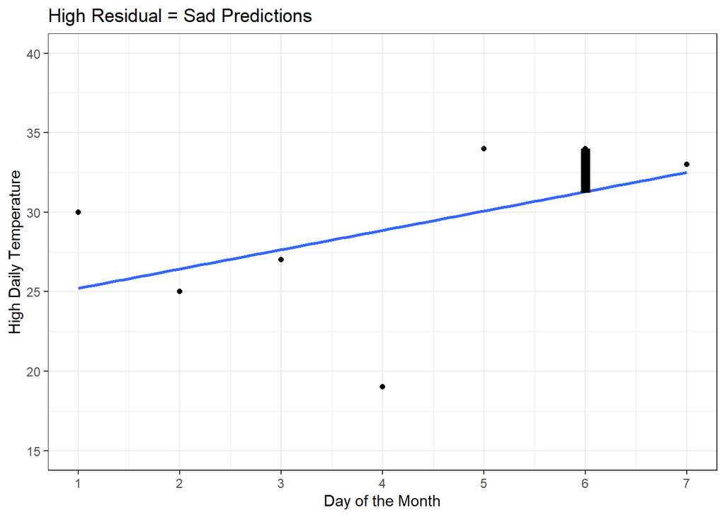

```r
ggplot(rex,aes(x=daysaway,y=high)) + geom_point() +
  geom_smooth(method='lm',se=FALSE,formula=y~x) + theme_bw() +
  labs(y='High Daily Temperature',x='Day of the Month',title='High Residual = Sad Predictions') + xlim(1,9) + ylim(15,40) + scale_x_continuous(breaks=seq(1,9,by=1)) +
  geom_segment(aes(x=6,xend=6,y=34,yend=31.2),size=3)
```

## SSE

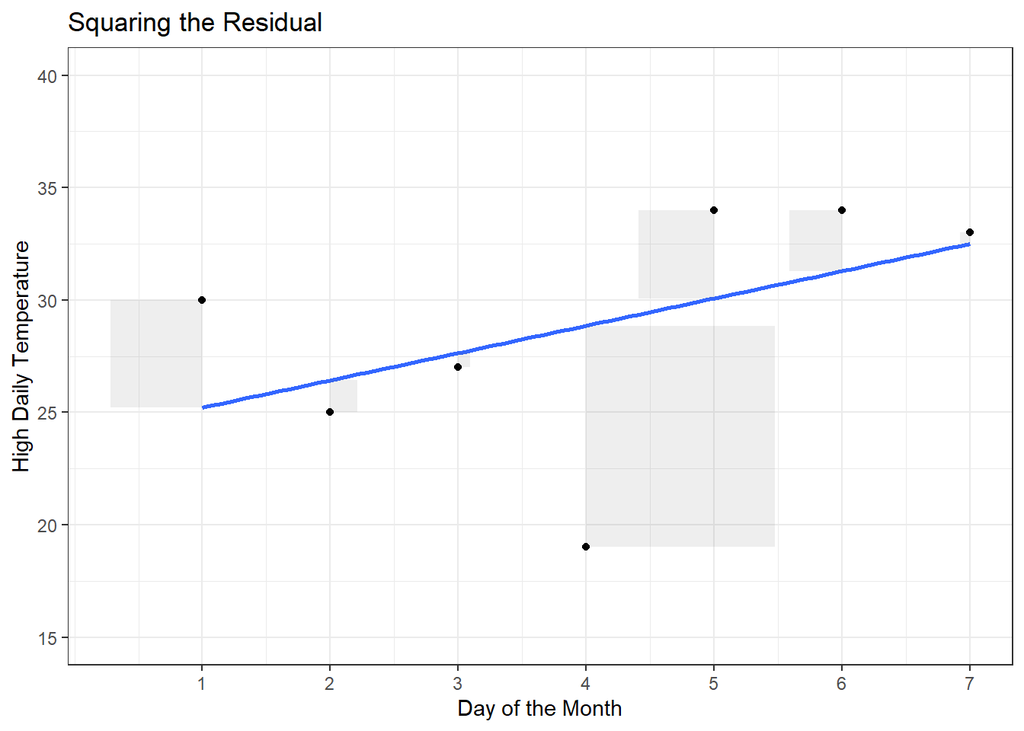

```r
ggplot(rex,aes(x=daysaway,y=high)) + geom_point() + geom_point(x=9,y=34.92857,size=3,color='green') +
  geom_smooth(method='lm',se=FALSE,formula=y~x) + theme_bw() +
  labs(y='High Daily Temperature',x='Day of the Month',title='Squaring the Residual') + xlim(1,9) + ylim(15,40) +
  geom_rect(aes(xmin=daysaway,xmax=daysaway-rex.lm$residuals*.15,ymin=high,ymax=rex.lm$fitted.values),alpha=0.1) + scale_x_continuous(breaks=seq(1,9,by=1))
```

If we add up all of these squares, the number we get is called the *Sum of Squared Error* (or SSE). In math we can write this as
$$SSE = \sum_{i=1}^n (Y_i -
\hat{Y}_i)^2$$
You’ll recognize the middle part from our residual, which just means we’re squaring each of those and then adding all of them together. It’s a great way of judging whether or not your regression is close to your data. If SSE is small, that means your residuals are small, and your regression is a good, tight fit. The best it can be is 0, which means our regression is perfect.

## Let’s Ignore the Dots Now

Now that we have our model, we can also make a general comparison to the whole of our dataset. If we had no x-axis, no explanatory variable, the best prediction we could make is by guessing the mean. This is $\bar{Y}$, because on the graph it looks like a bar stretching across. If this was the best we had, it wouldn’t matter if we tried to make a linear regression because it would be no better than a plan ol’ average. So how much better is a regression? Let’s compare! (*M*ean is *M*aroon)

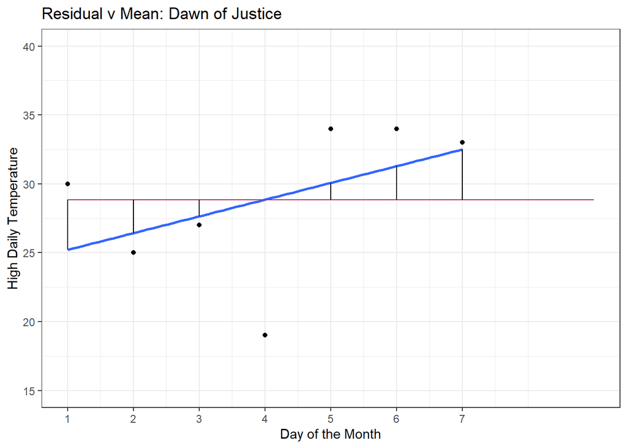

```r
ggplot(rex,aes(x=daysaway,y=high)) + geom_point() +
  geom_smooth(method='lm',se=FALSE,formula=y~x) + theme_bw() +
  labs(y='High Daily Temperature',x='Day of the Month',title='Residual v Mean: Dawn of Justice') + xlim(1,9) + ylim(15,40) +
  geom_segment(aes(x=1,xend=9,y=mean(high),yend=mean(high)),color='maroon') +
  geom_segment(aes(x=daysaway,xend=daysaway,y=mean(high),yend=rex.lm$fitted.values)) +
  scale_x_continuous(breaks=seq(1,7,by=1))
```

This is similar to our residual, but instead of finding the distance between 1) our observed points and 2) the regression, we can find the distance between each point’s expected value (on the $\hat{Y}_i$) and our mean ($\bar{Y}$). If we do the same thing we did to find the SSE (square that distance and then add them together) we’ll find our *Sum of Squared Regression (Error)*, or SSR.
$$SSR = \sum_{i=1}^n (\hat{Y}_i -
\bar{Y})^2$$
This is useful in a different way from what we had before, SSE. That one tells us how “bad” our model still is (what we still don’t understand), while the Sum of Squared Regression tells us how “good” the model is (how much better it is than a basic guess)

## Bringing them Together

Right now we have two ways of measuring: SSE (observed-predicted) and SSR (predicted-average). These are two ways of measuring variation in our regression. Is there another way?

Both SSE and SSR are built from our predicted model, the regression. What if we ignored it? Instead of comparing with our regression, let’s see what happens if we just find the deviation of average & observed.

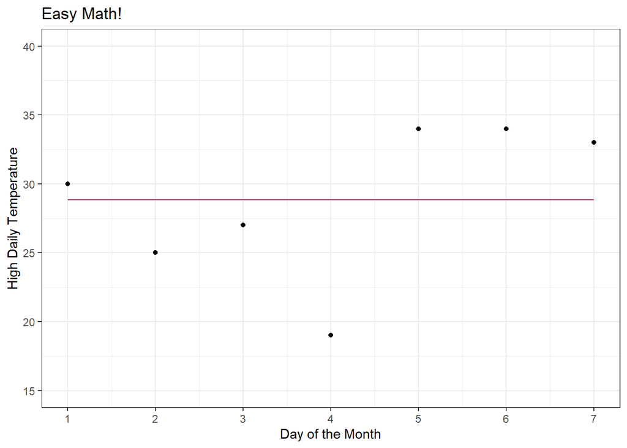

```r
ggplot(rex,aes(x=daysaway,y=high)) + geom_point() +
  theme_bw() +
  labs(y='High Daily Temperature',x='Day of the Month',title='Easy Math!') + xlim(1,7) + ylim(15,40) +
  geom_segment(aes(x=1,xend=7,y=mean(high),yend=mean(high)),color='maroon') +
  scale_x_continuous(breaks=seq(1,7,by=1))
```

This graph is essentially a worst-case scenario. We have no new information about the individual data, and all of the deviation is pretty big. It is going to be worse than the SSE, because we haven’t done any work to try and minimze it. However, if this and the SSE are pretty close to each other, that means the slope of our regression is pretty shallow, because the squares that we are adding together haven’t changed very much.

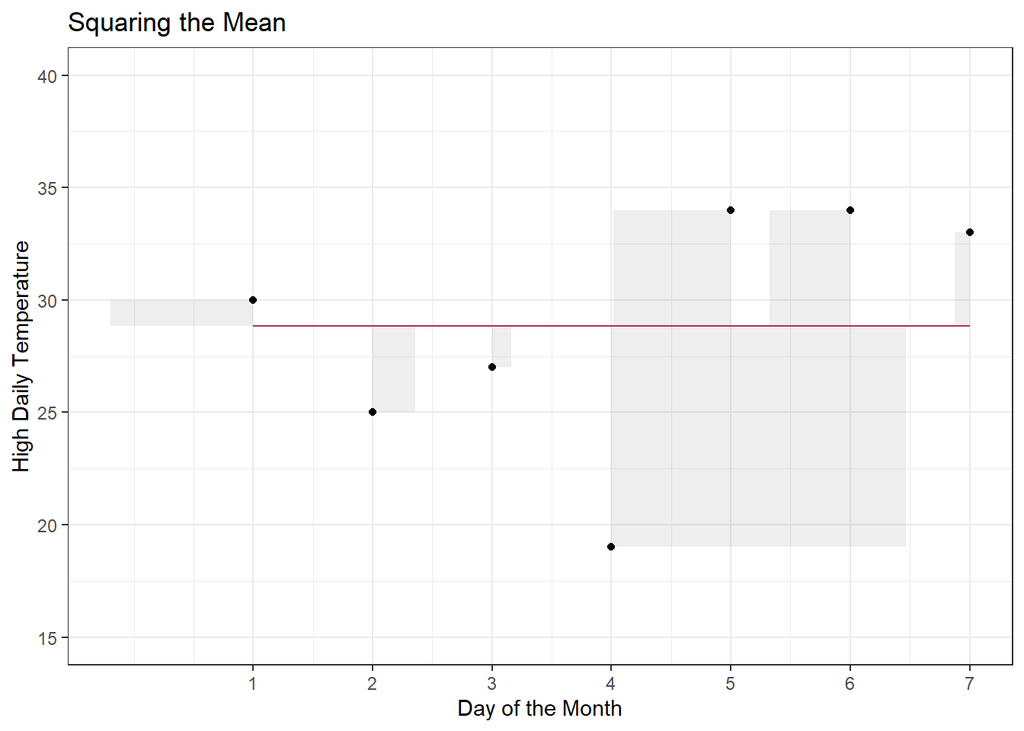

```r
ggplot(rex,aes(x=daysaway,y=high)) + geom_point() + theme_bw() +
  labs(y='High Daily Temperature',x='Day of the Month',title='Squaring the Mean') + xlim(1,7) + ylim(15,40) +
  geom_segment(aes(x=1,xend=7,y=mean(high),yend=mean(high)),color='maroon') +
  geom_rect(aes(xmin=daysaway,xmax=daysaway-rex.lm$residuals*.25,ymin=high,ymax=mean(high)),alpha=0.1) + scale_x_continuous(breaks=seq(1,7,by=1))
```

This highest deviance, this total variation, is called *Total Sum of Squares* or SSTO. This statistic isn’t very valuable on its own, but it becomes the foundation to figuring out exactly how useful our regression’s SSE is compared to our basic mean’s SSR. In fact, if we add together our SSE (observed-predicted) + SSR (predicted-mean) we get SSTO (observed-mean)!
$$SSR + SSE = SSTO =
\sum_{i=1}^n (Y_i - \bar{Y})^2$$